# Foundations of Data Science Project - Diabetes Analysis

## Context

Diabetes is one of the most frequent diseases worldwide and the number of diabetic patients are growing over the years. The main cause of diabetes remains unknown, yet scientists believe that both genetic factors and environmental lifestyle play a major role in diabetes.

A few years ago research was done on a tribe in America which is called the Pima tribe (also known as the Pima Indians). In this tribe, it was found that the ladies are prone to diabetes very early. Several constraints were placed on the selection of these instances from a larger database. In particular, all patients were females at least 21 years old of Pima Indian heritage.

## Objective

Here, we are analyzing different aspects of Diabetes in the Pima Indians tribe by doing Exploratory Data Analysis.

## Data Dictionary

The dataset has the following information:

- Pregnancies: Number of times pregnant
- Glucose: Plasma glucose concentration over 2 hours in an oral glucose tolerance test
- BloodPressure: Diastolic blood pressure (mm Hg)
- SkinThickness: Triceps skin fold thickness (mm)
- Insulin: 2-Hour serum insulin (mu U/ml)
- BMI: Body mass index (weight in kg/(height in m)^2)
- DiabetesPedigreeFunction: A function that scores the likelihood of diabetes based on family history.
- Age: Age in years
- Outcome: Class variable (0: a person is not diabetic or 1: a person is diabetic)

## Q 1: Import the necessary libraries and briefly explain the use of each library (3 Marks)

```python
import numpy as np

import pandas as pd

import seaborn as sns

import matplotlib.pyplot as plt

%matplotlib inline
```

#### Write your Answer here:

Packages description. Numpy: offers comprehensive mathematical functions, random number generators, linear algebra routines, Fourier transforms, and more. Panda: is a fast, powerful, flexible and easy to use open source data analysis and manipulation tool. Seaborn: is data visualization library based on matplotlib. It provides a high-level interface for drawing attractive and informative statistical graphics. Pyplot: is a collection of functions that make matplotlib work like MATLAB. Each pyplot function makes some change to a figure: e.g., creates a figure, creates a plotting area in a figure, plots some lines in a plotting area, decorates the plot with labels, etc.

## Q 2: Read the given dataset (2 Marks)

```python
pima = pd.read_csv("diabetes.csv")
```

## Q3. Show the last 10 records of the dataset. How many columns are there? (2 Marks)

```python
pima.tail(10)
print('Shape of the dataset:', pima.shape)
print('Number of columns:', pima.shape[1])
```

```
Shape of the dataset: (768, 9)
Number of columns: 9
```

#### Write your Answer here:

The number of columns is 9.

## Q4. Show the first 10 records of the dataset (2 Marks)

```python
pima.head(10)
```

|  | Pregnancies | Glucose | BloodPressure | SkinThickness | Insulin | BMI | DiabetesPedigreeFunction | Age | Outcome |
| --- | --- | --- | --- | --- | --- | --- | --- | --- | --- |
| 0 | 6 | 148 | 72 | 35 | 79 | 33.600000 | 0.627 | 50 | 1 |
| 1 | 1 | 85 | 66 | 29 | 79 | 26.600000 | 0.351 | 31 | 0 |
| 2 | 8 | 183 | 64 | 20 | 79 | 23.300000 | 0.672 | 32 | 1 |
| 3 | 1 | 89 | 66 | 23 | 94 | 28.100000 | 0.167 | 21 | 0 |
| 4 | 0 | 137 | 40 | 35 | 168 | 43.100000 | 2.288 | 33 | 1 |
| 5 | 5 | 116 | 74 | 20 | 79 | 25.600000 | 0.201 | 30 | 0 |
| 6 | 3 | 78 | 50 | 32 | 88 | 31.000000 | 0.248 | 26 | 1 |
| 7 | 10 | 115 | 69 | 20 | 79 | 35.300000 | 0.134 | 29 | 0 |
| 8 | 2 | 197 | 70 | 45 | 543 | 30.500000 | 0.158 | 53 | 1 |
| 9 | 8 | 125 | 96 | 20 | 79 | 31.992578 | 0.232 | 54 | 1 |

## Q5. What do you understand by the dimension of the dataset? Find the dimension of the `pima` dataframe. (3 Marks)

```python
pima.shape
```

```
(768, 9)
```

#### Write your Answer here:

The dimension of the data set are the number of rows (768) and the number of columns (9).

## Q6. What do you understand by the size of the dataset? Find the size of the `pima` dataframe. (3 Marks)

```python
pima.size
```

```
6912
```

#### Write your Answer here:

Size is used to get the number of elements in the object. It returns the number of rows if Series. Otherwise, if DataFrame (which is this case) returns the number of rows times the number of columns.

## Q7. What are the data types of all the variables in the data set? (2 Marks)

**Hint: Use the info() function to get all the information about the dataset.**

```python
pima.info()
```

```
<class 'pandas.core.frame.DataFrame'>
RangeIndex: 768 entries, 0 to 767
Data columns (total 9 columns):
 #   Column                    Non-Null Count  Dtype
---  ------                    --------------  -----
 0   Pregnancies               768 non-null    int64
 1   Glucose                   768 non-null    int64
 2   BloodPressure             768 non-null    int64
 3   SkinThickness             768 non-null    int64
 4   Insulin                   768 non-null    int64
 5   BMI                       768 non-null    float64
 6   DiabetesPedigreeFunction  768 non-null    float64
 7   Age                       768 non-null    int64
 8   Outcome                   768 non-null    int64
dtypes: float64(2), int64(7)
memory usage: 54.1 KB
```

#### Write your Answer here:

Integer: Pregnancies, Glucose, BloodPresurre,SkinThickness, Insuline, Age, Outcome. Float: BMI, DiabetesPediigreeFunction.

## Q8. What do we mean by missing values? Are there any missing values in the `pima` dataframe? (4 Marks)

```python
pima.isnull().values.any()
```

```
False
```

#### Write your Answer here:

Missiing values are certaiin valus whch are not specified. There are no missing values across all the columns and rows on ths dataset.

## Q9. What do the summary statistics of the data represent? Find the summary statistics for all variables except 'Outcome' in the `pima` data. Take one column/variable from the output table and explain all its statistical measures. (5 Marks)

```python
print(pima.iloc[: , 0 : 8].describe().T)

#Take statistics info from the first column
pima.iloc[:,0].describe().T
```

```
                          count        mean        std     min       25%  \
Pregnancies               768.0    3.845052   3.369578   0.000   1.00000
Glucose                   768.0  121.675781  30.436252  44.000  99.75000
BloodPressure             768.0   72.250000  12.117203  24.000  64.00000
SkinThickness             768.0   26.447917   9.733872   7.000  20.00000
Insulin                   768.0  118.270833  93.243829  14.000  79.00000
BMI                       768.0   32.450805   6.875374  18.200  27.50000
DiabetesPedigreeFunction  768.0    0.471876   0.331329   0.078   0.24375
Age                       768.0   33.240885  11.760232  21.000  24.00000

                               50%        75%     max
Pregnancies                 3.0000    6.00000   17.00
Glucose                   117.0000  140.25000  199.00
BloodPressure              72.0000   80.00000  122.00
SkinThickness              23.0000   32.00000   99.00
Insulin                    79.0000  127.25000  846.00
BMI                        32.0000   36.60000   67.10
DiabetesPedigreeFunction    0.3725    0.62625    2.42
Age                        29.0000   41.00000   81.00
```

```
count    768.000000
mean       3.845052
std        3.369578
min        0.000000
25%        1.000000
50%        3.000000
75%        6.000000
max       17.000000
Name: Pregnancies, dtype: float64
```

#### Write your Answer here:

The summary statistics of the data represent diverse statistical informatoin per every column of the dataset. Pregnancies column: count 768.000000 --> Number of total rows or observations in the column. mean 3.845052 --> It sums up every observation divided by the number of observations. It's a central tendency measure. std 3.369578 --> The standard deviation is a quantity expressing by how much the members of a group differ from the mean value for the group. min 0.000000 --> Minimum value present on the data. 25% 1.000000 --> This quartile (Q1) is commonly expressed as the percentage (25%) of values in a set of data scores that fall below a given value. 50% 3.000000 --> This quartile (Q2) is commonly expressed as the percentage (50%) of values in a set of data scores that fall below a given value. 75% 6.000000 --> This quartile (Q3) is commonly expressed as the percentage (75%) of values in a set of data scores that fall below a given value. max 17.000000 --> Maximum value present on the data.

## Q 10. Plot the distribution plot for the variable 'BloodPressure'. Write detailed observations from the plot. (2 Marks)

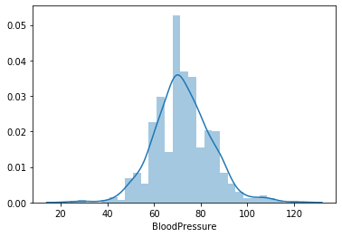

```python
sns.distplot(pima['BloodPressure'], kde = True)
```

#### Write your Answer here:

The blood pressure distribution is aproximately gaussian. The most tipical value is just in the middle (about 70).

## Q 11. What is the 'BMI' of the person having the highest 'Glucose'? (2 Marks)

```python
pima[pima['Glucose'] == pima['Glucose'].max()]['BMI']
```

```
661    42.9
Name: BMI, dtype: float64
```

#### Write your Answer here:

The BMI of the person having the highest glucose is 42.9.

## Q12.

### 12.1 What is the mean of the variable 'BMI'?

### 12.2 What is the median of the variable 'BMI'?

### 12.3 What is the mode of the variable 'BMI'?

### 12.4 Are the three measures of central tendency equal?

### (4 Marks)

```python
m1 = pima['BMI'].mean()  # mean
print(m1)

m2 = pima['BMI'].median()  # median
print(m2)

m3 = pima['BMI'].mode()[0]  # mode
print(m3)
```

```
32.45080515543617
32.0
32.0
```

#### Write your Answer here:

Mean: 32.45080515543617. Median: 32.0. Mode: 32.0. The measure of central tendency are not equal. The mode is the most commonly occurring value in a distribution. The median is the middle value in distribution when the values are arranged in ascending or descending order. The mean is the sum of the value of each observation in a dataset divided by the number of observations. This is also known as the arithmetic average. Every specific central tendency measure has is advantages and disadvantages. For example, the mode has an advantage over the median and the mean as it can be found for both numerical and categorical (non-numerical) data. REGarding the limitations of the mode, in some distributions, the mode may not reflect the centre of the distribution very well.

## Q13. How many women's 'Glucose' levels are above the mean level of 'Glucose'? (2 Marks)

```python
pima[pima['Glucose'] > pima['Glucose'].mean()].shape[0]
```

```
343
```

#### Write your Answer here:

The total number os women who has glucose levels above the mean level of glucose is 343.

## Q14. How many women have their 'BloodPressure' equal to the median of 'BloodPressure' and their 'BMI' less than the median of 'BMI'? (2 Marks)

```python
pima[(pima['BloodPressure'] == pima['BloodPressure'].median()) & (pima['BMI'] < pima['BMI'].median())].shape[0]
```

[output not shown]

#### Write your Answer here:

The number of women who have blood pressure equal to the median of blood pressure and their BMI less than the median of BMI os 22.

## Q15. Create a pairplot for the variables 'Glucose', 'SkinThickness', and 'DiabetesPedigreeFunction'. Write your observations from the plot. (3 Marks)

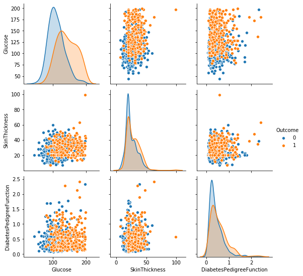

```python
sns.pairplot(data = pima, vars = ['Glucose', 'SkinThickness', 'DiabetesPedigreeFunction'], hue = 'Outcome')
plt.show()
```

## Q16. Plot the scatterplot between 'Glucose' and 'Insulin'. Write your observations from the plot. (4 Marks)

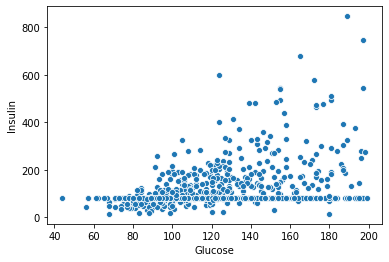

```python
sns.scatterplot(x = 'Glucose', y = 'Insulin', data = pima)
plt.show()
```

#### Write your Answer here:

The graph has a pattern which is the more glucose levels yo have, the more insuline levels you get, in general. Also there's a pettern for certain people who have the same levels of glucose and insulin.

## Q 17. Plot the boxplot for the 'Age' variable. Are there outliers? (2 Marks)

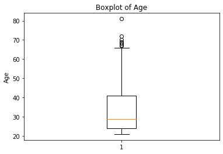

```python
plt.boxplot(pima['Age'])

plt.title('Boxplot of Age')
plt.ylabel('Age')
plt.show()
```

#### Write your Answer here:

Yes, there are outliers. They appear at the top of the graph as dots.

## Q18. Plot histograms for the 'Age' variable to understand the number of women in different age groups given whether they have diabetes or not. Explain both histograms and compare them. (5 Marks)

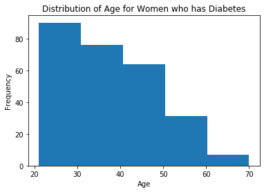

```python
plt.hist(pima[pima['Outcome'] == 1]['Age'], bins = 5)
plt.title('Distribution of Age for Women who has Diabetes')
plt.xlabel('Age')
plt.ylabel('Frequency')
plt.show()
```

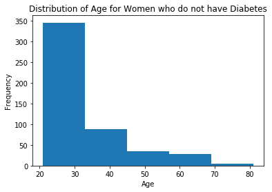

```python
plt.hist(pima[pima['Outcome'] == 0]['Age'], bins = 5)
plt.title('Distribution of Age for Women who do not have Diabetes')
plt.xlabel('Age')
plt.ylabel('Frequency')
plt.show()
```

## Q 19. What is the Interquartile Range of all the variables? Why is this used? Which plot visualizes the same? (5 Marks)

```python
Q1 = pima.quantile(0.25)
Q3 = pima.quantile(0.75)
IQR = Q3 - Q1
print(IQR)
```

```
Pregnancies                  5.0000
Glucose                     40.5000
BloodPressure               16.0000
SkinThickness               12.0000
Insulin                     48.2500
BMI                          9.1000
DiabetesPedigreeFunction     0.3825
Age                         17.0000
Outcome                      1.0000
dtype: float64
```

#### Write your Answer here:

Column IQR Pregnancies 5.0000 Glucose 40.5000 BloodPressure 16.0000 SkinThickness 12.0000 Insulin 48.2500 BMI 9.1000 DiabetesPedigreeFunction 0.3825 Age 17.0000 Outcome 1.0000 The boxplot visualizes also the interquartile range. The IQR is used to capture the sample rates between 75 % and 25 % of the data.

## Q 20. Find and visualize the correlation matrix. Write your observations from the plot. (3 Marks)

```python
corr_matrix = pima.iloc[ : ,0 : 8].corr

corr_matrix
```

[output not shown]

```python
plt.figure(figsize = (8, 8))
sns.heatmap(corr_matrix, annot = True)

# Display the plot
plt.show()
```

[output not shown]